# StanとRでベイズ統計モデリング15

UPDATE: 2024-01-05 14:14:28.09333

# はじめに

このノートは「StanとRでベイズ統計モデリング」の内容を写経することで、ベイズ統計への理解を深めていくために作成している。

- [StanとRでベイズ統計モデリング](https://www.kyoritsu-pub.co.jp/bookdetail/9784320112421)
- [StanとRでベイズ統計モデリング サポートページ](https://github.com/MatsuuraKentaro/RStanBook)

基本的には気になった部分を写経しながら、ところどころ自分用の補足をメモすることで、「StanとRでベイズ統計モデリング」を読み進めるための自分用の補足資料になることを目指す。私の解釈がおかしく、メモが誤っている場合があるので注意。

今回は第11章「離散値をとるパラメータを使う」の後半から写経していく。

## 11.3 ゼロ過剰ポアソン分布

ある飲食店への来店回数を取得したデータをもとに来店回数が多い人の特徴を調べたい。来店回数はポアソン分布を仮定できそうではあるが、0が多いことから、ゼロ過剰ポアソン分布を利用するほうが望ましい。

- `Sex`: 0が男性、1が女性
- `Sake`: 0が飲まない、1が飲む

```r
library(dplyr)
library(rstan)
library(ggplot2)
library(GGally)

options(max.print = 999999)
rstan_options(auto_write=TRUE)
options(mc.cores=parallel::detectCores())

d <- read.csv('https://raw.githubusercontent.com/MatsuuraKentaro/RStanBook/master/chap11/input/data-ZIP.txt')
head(d)
```

```
##   Sex Sake Age Y
## 1   0    1  18 5
## 2   1    0  18 2
## 3   1    1  18 1
## 4   0    0  19 3
## 5   0    0  19 5
## 6   1    0  19 7
```

## 11.3.1 解析目的とデータの分布の確認

解析の目的は「リピーターになりそうな人を知りたい」とする。また「説明変数でリピーターになるかをどれほど予測できるかを知りたい、影響度合いも知りたい」とする。

- 1行1列目のグラフから、女性が少なそう
- 2行2列目のグラフから、お酒を飲む人が少なそう
- 3行3列目のグラフから、年齢に特徴はなさそう
- 4行4列目のグラフから、来店回数が0が突出して多く、0を除くと正規分布のような形状
- 4行1列目のグラフから、女性だと来店回数が少なそう
- 4行3列目のグラフから、年齢が高いと来店回数が多くなりそう
- 2行4列目のグラフから、お酒を飲むかつ来店回数が0の人が少ないため順位相関係数が少し高い

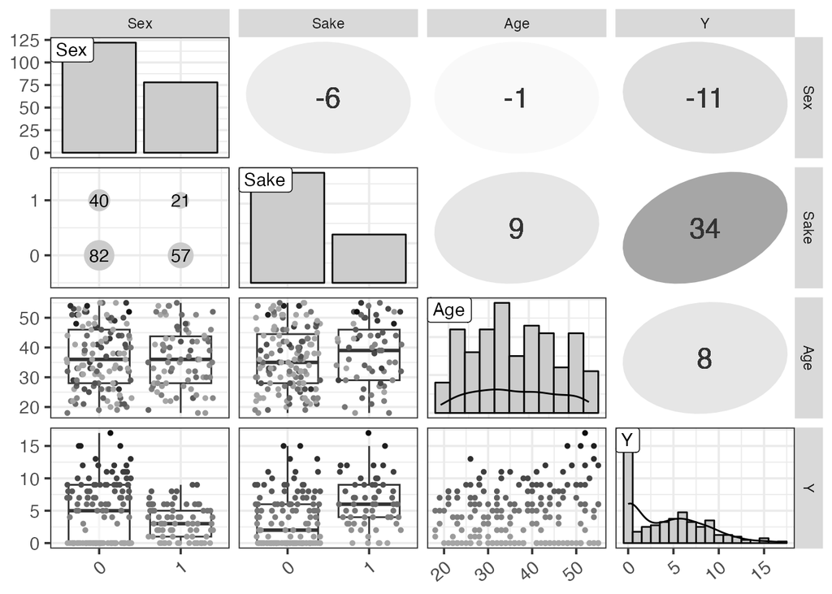

```r
d$Sex <- as.factor(d$Sex)
d$Sake <- as.factor(d$Sake)

N_col <- ncol(d)
ggp <- ggpairs(d, upper = 'blank', diag = 'blank', lower = 'blank')

# 対角成分のヒストグラムを作成
for (i in 1:N_col) {
  x <- d[,i]
  p <- ggplot(data.frame(x), aes(x = x)) +
    theme_bw(base_size = 14) +
    theme(axis.text.x = element_text(angle = 40, vjust = 1, hjust = 1))
  if (class(x) == 'factor') {
    p <- p + geom_bar(color = 'grey5', fill = 'grey80')
  } else {
    bw <- ifelse(colnames(d)[i] == 'Y', 1, (max(x)-min(x))/10)
    p <- p + geom_histogram(binwidth = bw, color = 'grey5', fill = 'grey80') +
      geom_line(aes(y = after_stat(count)*bw), stat = 'density')
  }
  p <- p + geom_label(data = data.frame(x = -Inf, y = Inf, label = colnames(d)[i]), aes(x = x, y = y, label = label), hjust = 0, vjust = 1)
  ggp <- putPlot(ggp, p, i, i)
}

# 上三角成分の相関係数を作成
zcolat <- seq(-1, 1, length = 81)
zcolre <- c(zcolat[1:40]+1, rev(zcolat[41:81]))

for (i in 1:(N_col-1)) {
  for (j in (i+1):N_col) {
    x <- as.numeric(d[,i])
    y <- as.numeric(d[,j])
    r <- cor(x, y, method = 'spearman', use = 'pairwise.complete.obs')
    zcol <- lattice::level.colors(r, at = zcolat, col.regions = grey(zcolre))
    textcol <- ifelse(abs(r) < 0.4, 'grey20', 'white')
    ell <- ellipse::ellipse(r, level = 0.95, type = 'l', npoints = 50, scale = c(.2, .2), centre = c(.5, .5))
    p <- ggplot(data.frame(ell), aes(x = x, y = y)) + theme_bw() + theme(
      plot.background = element_blank(),
      panel.grid.major = element_blank(), panel.grid.minor = element_blank(),
      panel.border = element_blank(), axis.ticks = element_blank()) +
      geom_polygon(fill = zcol, color = zcol) +
      geom_text(data = NULL, x = .5, y = .5, label = 100*round(r, 2), size = 6, col = textcol)
    ggp <- putPlot(ggp, p, i, j)
  }
}

# 下三角成分の箱ヒゲ図を作成
for (j in 1:(N_col-1)) {
  for (i in (j+1):N_col) {
    x <- d[,j]
    y <- d[,i]
    if (class(x) == 'factor' && class(y) == 'factor') {
      p <- ggplot(reshape2::melt(table(x,y)), aes(x = x, y = y)) +
        theme_bw(base_size = 14) +
        geom_point(aes(size = value), color = 'grey80') +
        geom_text(aes(label = value)) +
        scale_size_area(max_size = 8) +
        scale_x_continuous(breaks = 0:1, limits = c(-0.5,1.5)) + scale_y_continuous(breaks = 0:1, limits = c(-0.5,1.5))
    } else {
      p <- ggplot(data.frame(x, y, Y = as.numeric(d$Y)), aes(x = x, y = y, color = Y)) +
        theme_bw(base_size = 14) +
        theme(axis.text.x = element_text(angle = 40, vjust = 1, hjust = 1))
      if (class(x) == 'factor') {
        p <- p + geom_boxplot(alpha = 3/6, outlier.size = 0, fill = 'white') +
          geom_point(position = position_jitter(w = 0.4, h = 0), size = 1)
      } else {
        p <- p + geom_point(size = 1)
      }
      p <- p + scale_color_gradient(low = 'grey65', high = 'grey5')
    }
    ggp <- putPlot(ggp, p, i, j)
  }
}
print(ggp, left = 0.3, bottom = 0.3)
```

## 11.3.2 メカニズムの想像

来店回数$Y$の0が突出している点が特徴的なので、このメカニズムを考える。1人が来店するメカニズムとして、「とにかく1回来店する」場合と「気に入って複数回来店する」場合のパターンがある。そして、とにかく1回来店するのは確率$q$のベルヌイ分布に従うと考え、リピーターの来店回数は平均$\lambda$のポアソン分布に従うと考える。

つまり、確率$q$のコインを投げて、裏が出れば来店回数は0、表が出れば平均$\lambda$のポアソン分布に従って生成される。そして、$q$はロジスティック回帰、$\lambda$はポアソン回帰でパラメタの推定を分ける。コイン投げは離散パラメタとなるので、周辺化消去が必要になる。

$y=0$のときは「ベルヌイ分布で0が出る確率」と「ベルヌイ分布で1が出る確率」と「ポアソン分布で0が出る確率」の和となる。$y=0$のときはベルヌイ分布の可能性が高いが、$y=1$のときはどちらの分布か判断し難くく、$y\ge2$のときはポアソン分布に従うと考える。そのため、$Bernoulli(0|q) + Bernoulli(1|q) × Poisson(y=0|\lambda)$とする。

$$\begin{eqnarray}
ZIP(y|q,\lambda)
=
\begin{cases}
Bernoulli(0|q) + Bernoulli(1|q) × Poisson(y=0|\lambda) \ if \ y = 0
\\
Bernoulli(1|q) × Poisson(y|\lambda) \ if \ y \ge 1 \\
\end{cases}
\end{eqnarray}$$

## 11.3.3 モデル式の記述

$\boldsymbol{ X }$はN×4の行列で、$\overrightarrow{ b}$は長さ4のベクトル。

モデル11-7

$$\begin{eqnarray}
q[n] &=& inv\_logit((\boldsymbol{ X } \overrightarrow{
b_{1}})[n]) \\
\lambda[n] &=& (\boldsymbol{ X } \overrightarrow{ b_{2}})[n] \\
Y[n] &\sim& ZIP(q[n], \lambda[n])
\end{eqnarray}$$

## 11.3.4 Stanで実装

Stanのモデルは下記の通り。

```
functions {
  real ZIP_lpmf(int Y, real q, real lambda) {
    if (Y == 0) {
      return log_sum_exp(
        bernoulli_lpmf(0 | q),
        bernoulli_lpmf(1 | q) + poisson_log_lpmf(0 | lambda)
      );
    } else {
      return bernoulli_lpmf(1 | q) + poisson_log_lpmf(Y | lambda);
    }
  }
}

data {
  int N;
  int D;
  int<lower=0> Y[N];
  matrix[N,D] X;
}

parameters {
  vector[D] b[2];
}

transformed parameters {
  vector[N] q_x;
  vector[N] q;
  vector[N] lambda;

  q_x = X*b[1];
  lambda = X*b[2];
  for (n in 1:N)
    q[n] = inv_logit(q_x[n]);
}

model {
  for (n in 1:N)
    Y[n] ~ ZIP(q[n], lambda[n]);
}
```

## 11.3.5 推定結果の解釈

データを用意する。

```r
d$Age <- d$Age/10
X <- cbind(1, d[,-ncol(d)])
data <- list(N = nrow(d), D = ncol(X), Y = d$Y, X = X)
data
```

```
## $N
## [1] 200
##
## $D
## [1] 4
##
## $Y
##   [1]  5  2  1  3  5  7  5  0  8  8  0  7  6  0  0  1  4  0  0  3  0  0  4  8  7
##  [26]  3  7  0  2  4  0  9  0  7  0  0  9  4  6  1 13  5  7  1  6  2 10  0  2  1
##  [51]  6  9  0  9  8  3 11  4  0  6  3  1  4  3  0  0  5  0  8  7  2  4  0  7  6
##  [76]  5  0  0  0  4  2 11 10  5  0  0  0  0  0  2  7 11  0  3  6  4  1  0  0  5
## [101]  0  0  6  0  5  9  0  0 10  0  2  0  6 10  6  8  5  8  9  3  6  5  9  0  0
## [126] 11  3  0  5  6  6  7  9  2  0 12  0  0  5  4  0  0  7  0  9  6  0  4  8  0
## [151]  0  4  0  8  6  3  8 11  0  7  0 15  0  0  0  9  0 12  0  9  7  9  0 15  9
## [176]  6  3  0  0  0 12  2  9  5 17  6  0  0 10 15  0  0  5  4 13  6  0  0 12  6
```

[output cut: 203 more lines]

ここでは、`stan_model()`関数で最初にコンパイルしておいてから、

```r
model117 <- stan_model('note_ahirubayes15-117.stan')
```

`sampling()`関数でサンプリングする。

```r
fit <- sampling(object = model117, data = data, seed = 1989)
```

推定結果は下記の通り。`b[1,]`は来店確率に関わる回帰係数で、`b[2,]`はリピーターが何回来店するかに関わる回帰係数。`b[,1−4]`は切片、`Sex`、`Sake`、`Age`に対応する。`Age`は10で割っているので、10倍する必要がある。1回来る来店確率が高いのは、「女性(`b[1,2]=1.6`)でお酒を飲んでいる人(`b[1,3]=3.4`)」である。リピーターになる確率が高いのは、「男性(`b[2,2]=-0.7`)でお酒を飲んでいない人(`b[2,3]=-0.2`)で、年齢が高い人(`b[2,4]=0.2`)」である。

```r
print(fit, prob = c(0.025, 0.5, 0.975), pars = c('b', 'q', 'lambda'), digits_summary = 1)
```

[output not shown]

[output cut: 363 more lines]

```
## lambda[191]  1.8       0 0.1  1.6  1.8   1.9  2880    1
## lambda[192]  2.5       0 0.1  2.4  2.5   2.7  2920    1
## lambda[193]  1.6       0 0.1  1.4  1.6   1.8  2243    1
## lambda[194]  1.8       0 0.1  1.6  1.8   1.9  2880    1
## lambda[195]  2.5       0 0.1  2.4  2.5   2.7  2920    1
## lambda[196]  2.4       0 0.1  2.2  2.4   2.5  3310    1
## lambda[197]  2.5       0 0.1  2.4  2.5   2.7  2918    1
## lambda[198]  2.5       0 0.1  2.4  2.5   2.7  2918    1
## lambda[199]  2.4       0 0.1  2.2  2.4   2.5  3310    1
## lambda[200]  1.8       0 0.1  1.6  1.8   2.0  2850    1
##
## Samples were drawn using NUTS(diag_e) at Fri Jan  5 14:14:40 2024.
## For each parameter, n_eff is a crude measure of effective sample size,
## and Rhat is the potential scale reduction factor on split chains (at
## convergence, Rhat=1).
```

$q, \lambda$の順位相関係数の中央値は負であるため、来店確率が高いことと、リピーターで多数来店することは、負の関係がある。

```r
ms <- rstan::extract(fit)
N_mcmc <- length(ms$lp__)
r <- sapply(1:N_mcmc,
            function(i) cor(ms$lambda[i,], ms$q[i,], method = 'spearman'))
quantile(r, prob = c(0.025, 0.25, 0.5, 0.75, 0.975))
```

```
##       2.5%        25%        50%        75%      97.5%
## -0.8081299 -0.6974237 -0.6496459 -0.6050023 -0.4827052
```

## 参考文献および参考資料

- [StanとRでベイズ統計モデリング](https://www.kyoritsu-pub.co.jp/bookdetail/9784320112421)
- [StanとRでベイズ統計モデリング サポートページ](https://github.com/MatsuuraKentaro/RStanBook)
- [Stan Reference Manual](https://mc-stan.org/docs/reference-manual/index.html)